# Part A

## Question 1:

##### Measures The Strength of Relationships between People in A Mapped Network of People.

To answer this question, we would like to utilize a package to analyse the connection from Collin, Boris and Rachel networks.

### Methods

- `networkx` package
- https://networkx.github.io/documentation/stable/

### Features

Some Features would apply into this network analysis model:

- phone or email, combining into a feature.
- network owner: Collin, Rachel and Boris
- networks' connections

### Findings

- Collin has most strong connections in the network.
- 18 people with 3rd degree have high strength connections with Collin, Boris and Rachel.

## Import Packages

```python
## basic
import itertools
import pandas as pd
pd.set_option('display.max_columns', 2000)
import numpy as np
%matplotlib inline
import matplotlib.pyplot as plt
plt.style.use('fivethirtyeight')
import seaborn as sns
sns.set(rc={"figure.figsize": (15, 9)})
from scipy import stats
import missingno as msno

## data process
from sklearn.preprocessing import LabelEncoder

## network model
import networkx as nx
```

```python
class MultiColumnLabelEncoder:
    def __init__(self,columns = None):
        self.columns = columns

    def fit(self,X,y=None):
        return self

    def transform(self,X):
        '''
        transform columns of X specified in self.columns using
        LabelEncoder(). If no columns specified, transform all
        columns in X.
        '''
        output = X.copy()
        if self.columns is not None:
            for col in self.columns:
                output[col] = LabelEncoder().fit_transform(output[col])
        else:
            for colname,col in output.iteritems():
                output[colname] = LabelEncoder().fit_transform(col)
        return output

    def fit_transform(self,X,y=None):
        return self.fit(X,y).transform(X)
```

### I. Read Files

```python
df_xls = pd.ExcelFile('../data/data.xlsx')
df_collin = pd.read_excel(df_xls, 'Collin')
df_rachel = pd.read_excel(df_xls, 'Rachel')
df_boris = pd.read_excel(df_xls, 'Boris')
```

```python
df_collin.head(3)
```

|  | first_name | last_name | email | phone | company | job_title | country_of_origin | country_of_residence |
| --- | --- | --- | --- | --- | --- | --- | --- | --- |
| 0 | Chan | Blogg | cblogg0@comsenz.com | NaN | Bluejam | Tax Accountant | China | NaN |
| 1 | Lebbie | Talman | ltalman1@nydailynews.com | NaN | Demimbu | Technical Writer | Netherlands | NaN |
| 2 | Dewie | Petegrew | dpetegrew2@list-manage.com | NaN | Jazzy | Chemical Engineer | Mongolia | NaN |

```python
df_collin.shape
```

```
(858, 8)
```

```python
df_rachel.shape
```

```
(801, 8)
```

```python
df_boris.shape
```

```
(862, 8)
```

### II. Explore Data

##### 1. Merge Data for Processing and Cleaning

```python
df_collin['network'] = 'collin'
df_rachel['network'] = 'rachel'
df_boris['network'] = 'boris'

## concate three people data
concat = [df_collin, df_rachel, df_boris]
df_concat = pd.concat(concat)
```

```python
df_concat.shape
```

```
(2521, 9)
```

##### 2. Check Missing Data

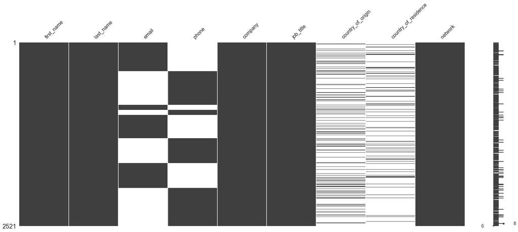

```python
msno.matrix(df_concat)
```

```python
df_concat.head(3)
```

|  | first_name | last_name | email | phone | company | job_title | country_of_origin | country_of_residence | network |
| --- | --- | --- | --- | --- | --- | --- | --- | --- | --- |
| 0 | Chan | Blogg | cblogg0@comsenz.com | NaN | Bluejam | Tax Accountant | China | NaN | collin |
| 1 | Lebbie | Talman | ltalman1@nydailynews.com | NaN | Demimbu | Technical Writer | Netherlands | NaN | collin |
| 2 | Dewie | Petegrew | dpetegrew2@list-manage.com | NaN | Jazzy | Chemical Engineer | Mongolia | NaN | collin |

```python
cols = ['phone', 'first_name','last_name']
df_concat['email'] = df_concat['email'].fillna(df_concat['phone'], inplace=False)
df_concat = df_concat.rename(columns={'email':'email_phone'})
df_concat['first_last_name'] = df_concat['first_name'] + '_' + df_concat['last_name']
df_concat = df_concat.drop(cols, axis=1)
```

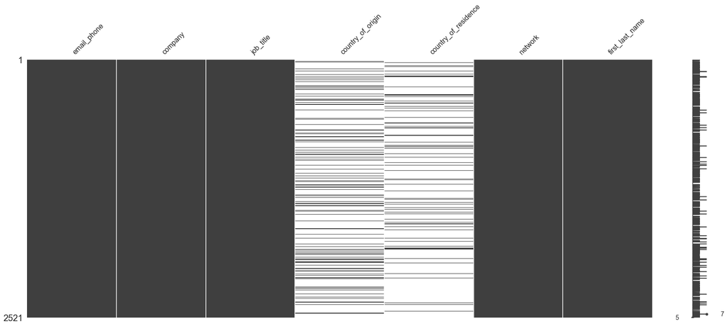

```python
msno.matrix(df_concat)
```

### III. Feature Engineering

```python
df_network = df_concat[['network','email_phone','first_last_name']]
df_network['email_phone_copy'] = df_network['email_phone']
```

```python
df_network = MultiColumnLabelEncoder(columns = ['email_phone']).fit_transform(df_network)
df_network.columns = ['network','unique_id','connect_name','email_phone']
```

```python
df_ntwork_concat = df_network.merge(
    df_network.rename(columns={'network':'network_2','connect_name':'connect_name_2','unique_id':'unique_id_2'}),
    on='email_phone'
)
df_ntwork_concat.shape
```

```
(3729, 7)
```

```python
## remove duplicated networks
df_ntwork_concat_drop_duplicate = df_ntwork_concat[df_ntwork_concat['network'] != df_ntwork_concat['network_2']]
```

```python
df_ntwork_concat_drop_duplicate.shape
```

```
(1150, 7)
```

### IV. Create Netwrok Models

```python
network_graph = nx.from_pandas_edgelist(
    df=df_ntwork_concat_drop_duplicate, source='unique_id', target='network', edge_attr='email_phone'
)
network_graph.add_nodes_from(nodes_for_adding=df_ntwork_concat_drop_duplicate['network'].tolist())
```

##### 1. Visualisation for Networks

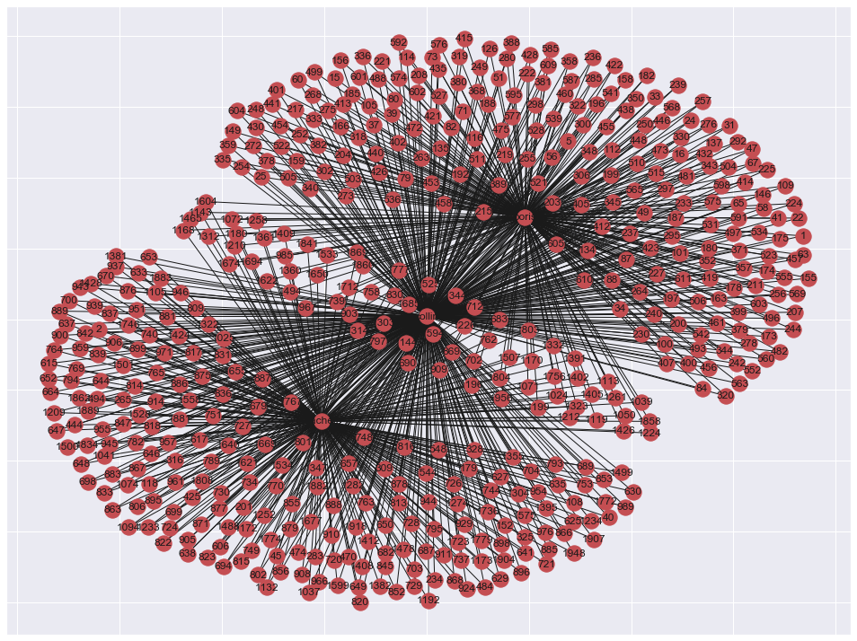

```python
sns.set(rc={"figure.figsize": (15, 12)})
nx.draw_networkx(
    network_graph, arrows=True, with_labels=True, node_color='r'
)
```

##### 2. Network Degrees

The network graph indicates:

- Collin has most strong connections in the network.
- 18 people have high connections with Collin, Boris and Rachel.

```python
network_connect_name = nx.from_pandas_edgelist(
    df=df_ntwork_concat_drop_duplicate, source='connect_name', target='network', edge_attr='email_phone'
)
network_connect_name.add_nodes_from(nodes_for_adding=df_ntwork_concat_drop_duplicate['network'].tolist())
```

```python
df_degree = pd.DataFrame(network_connect_name.degree, columns=['network','degree'])
df_degree[df_degree['degree'] >= 3].sort_values('degree', ascending=False)
```

|  | network | degree |
| --- | --- | --- |
| 1 | collin | 452 |
| 6 | boris | 290 |
| 2 | rachel | 282 |
| 79 | Glori_Illsley | 3 |
| 149 | Elana_Kevis | 3 |
| 148 | Carolyn_Haine | 3 |
| 147 | Benjie_Coxhell | 3 |
| 146 | Idaline_Hixley | 3 |
| 82 | Dicky_Sharrem | 3 |
| 81 | Jobi_Spilisy | 3 |
| 80 | Isacco_Staten | 3 |
| 77 | Tine_Wethered | 3 |
| 78 | Cosette_Paxton | 3 |
| 76 | Ariana_Carcass | 3 |
| 11 | Laney_Willmer | 3 |
| 10 | Kellia_Neesham | 3 |
| 9 | Osborne_Olman | 3 |
| 8 | Farlie_Reade | 3 |
| 7 | Frankie_Gates | 3 |
| 5 | Natasha_Goodhand | 3 |
| 150 | Wandie_Berfoot | 3 |

# Part B

## Question 4:

##### We need to figure out how to identify a person’s occupation, title or role given an incomplete set of information.

In this case, there are around 2,000 people with limited information but need to predict almost 200 different job titles. This is a multiple classification question with various outputs(y).

### Methods

In order to solve this case, some methods I will develop as following steps:

1. create a feature called `job_segment` to segment job titles in different groups. We will be based on `job_segment` to create different classification models for predicting outputs(y). For example:
   - Engineering: Chemical Engineer and Software Test Engineer III etc.
   - Finance: Tax Accountant and Financial Advisor etc.
   - Business_Development: Sales and Business Development Manager etc.
2. Features and Observations in this data set are insufficient so we will need to collect extra data from social media websites:
   - LinkedIn API
     - https://developer.linkedin.com/docs/v1/people/profile-api
     - https://developer.linkedin.com/docs/rest-api
     - https://docs.microsoft.com/en-us/linkedin/shared/integrations/people/profile-api
   - Facebook API
     - https://developers.facebook.com/docs/graph-api/reference/user/
     - https://towardsdatascience.com/how-to-use-facebook-graph-api-and-extract-data-using-python-1839e19d6999

### Features and Outputs

#### Engineering for Inputs

There are extra features would collect from LinkedIn API and Facebook API:

- Education and Major
- Personal Headline(usually show job title at xxx company)
- Industry
- Others
  - ex. country, location and work history

These features are very crucial information to implementing into segment-based training models.

#### Engineering for outputs

In regards to the output, need to build up a dictionary to attribute similar job titles into some categories, which would reduces output classes increases the prediction performance potentially. For example:

```
job_title_adjust = {
                    'Business Development Manager':['Sales Manger','Business Manager'],
                    'Soft Engineer':['Developer','back-end Engineer','Soft Engineer']
                    }
```

Therefore, we can reduce a segment-based model with less predicting output classes, which give us a better predicting outputs of scale.

### Challenges & Suggestions

To acquire extra information, integration and automation works with APIs might take some resources and times to develop but it is an important step before creating a well prediction model.